# Презентация к лабораторной работе 5

Выполнение

Власов Артем Сергеевич

1132246841@rudn.ru

Российский университет дружбы народов

# Информация

## Докладчик

- Власов Артем Сергеевич
- Студент
- Студент
- Российский университет дружбы народов им. П. Лумумбы
- 1132246841@rudn.ru
- https://vlasovas52.github.io/ru/

# Вводная часть

## Цели и задачи

Получить навыки управления системными службами операционной системы посредством systemd. Выполнить действия по запуску, определению статуса добавлению в автозапуск службы Very Secure FTP. Получить навыки для разрешения конфликта служб iptables и firewalld. Продемонстрировать навыки работы с изолированными целями.

# Выполнение лабораторной работы 5

Переходим на пользователя root и устанавливаем vsftpd.

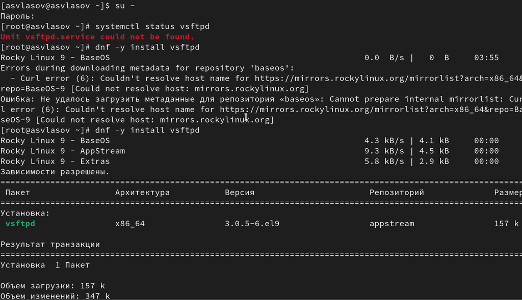

vsftpd

Смотрим статус службы, затем добавив службу в автозапуск смотрим статус еще раз.

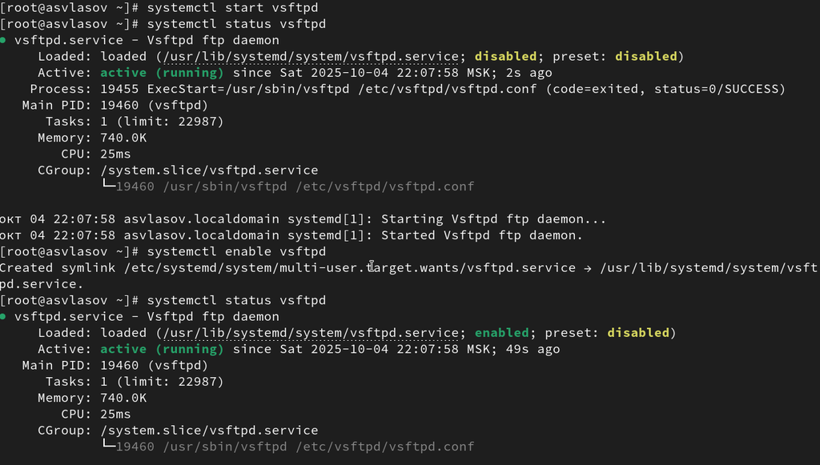

Статус службы

Убираем службу из автозапуска и смотрим снова.

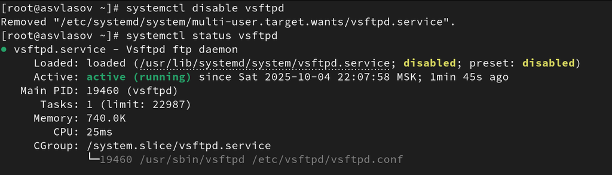

Статус изменения

Выводим на экран символические ссылки запуска служб. Видим, что если включить службу в автозапуск, она появляется в символических ссылках.

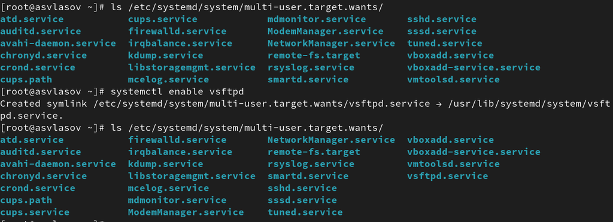

Символические ссылки

Выводим на экран список зависимостей юнита

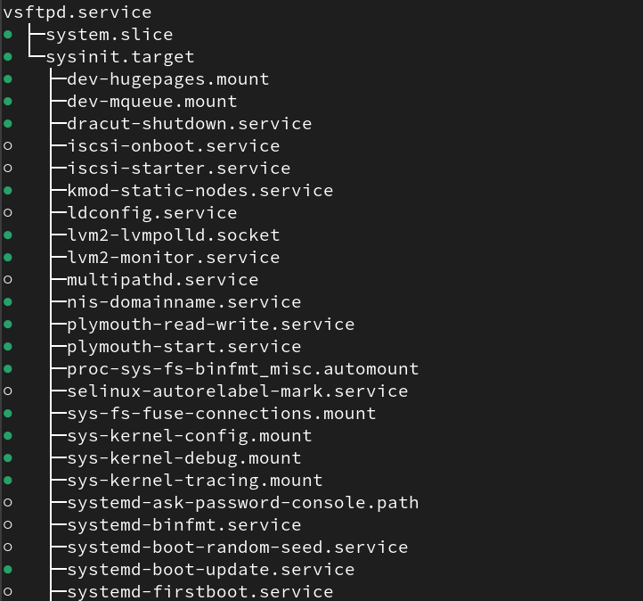

Юниты

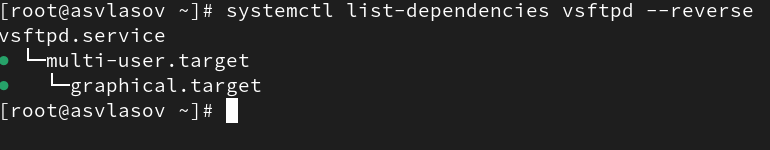

Зависимые юниты

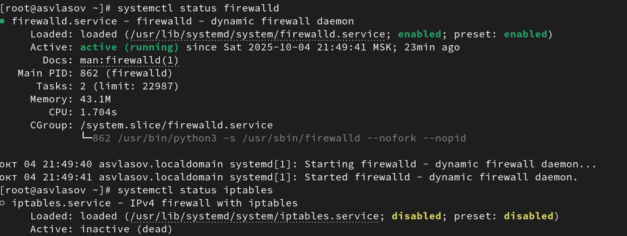

Статус служб

Провеярем настройки служб

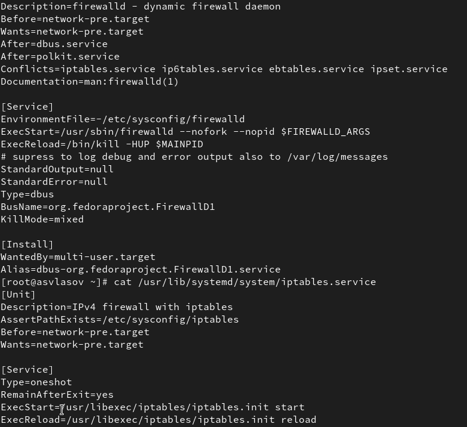

Настройки служб

Выгружаем службу iptables. Затем запускаем вторую службу, все приходит в норму. Блокируем запуск службы iptables

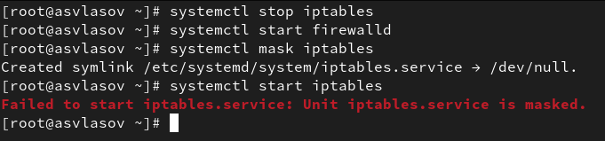

Блокировка службы

Пробуем поставить службу в автозапуск.

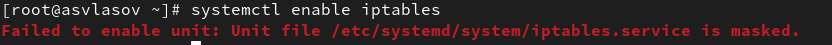

Ошибка

Список всех целей для изолирования. И загрузка системы в режиме восстановления.

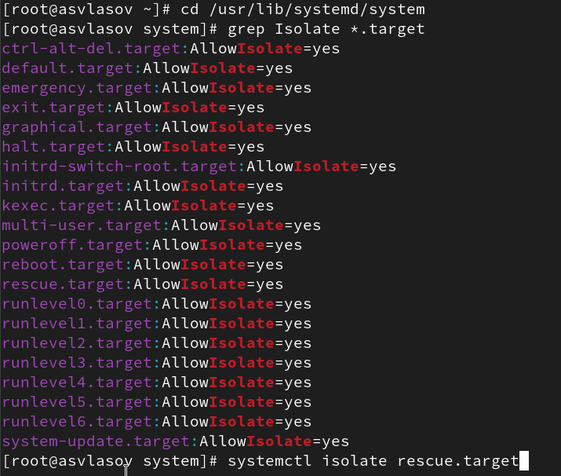

Изолирование

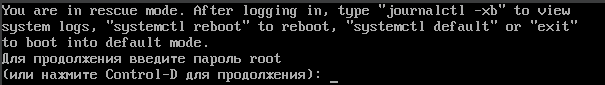

Режим восстановления

Запускаем систему с текстовом режиме с помощью multi-user.target. В текстовом режиме возвращаем графический режим.

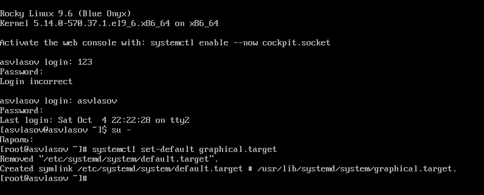

Текстовый режим

[figure not shown]

Графический режим

# Выводы

Мы получили навыки управления системными службами операционной системы посредством systemd.

[figure not shown]